# Simulating and interpreting SIR dynamics

In this walk through, we will be simulating an SIR model.

The SIR model is a simple compartmental model used to describe the spread of infectious diseases in a population. The model divides the population into three compartments: susceptible (S), infectious (I), and recovered (R) individuals. The model equations describe the flow of individuals between these compartments based on the transmission rate ($\beta$) and the recovery rate ($\gamma$).

We will be using the `{deSolve}` package to solve the model equations. The `{deSolve}` package is a powerful and flexible package for solving differential equations in R. It provides a wide range of solvers for different types of differential equations.

Here, we will use the `lsoda()` function from the `{deSolve}` package to solve the SIR model. The `lsoda()` function is a wrapper for the Livermore Solver for Ordinary Differential Equations (LSODA) developed by Hindmarsh and Petzold. It is a robust and efficient solver for stiff and non-stiff differential equations.

The `lsoda()` function takes, among others, the following arguments: - `func`: the model function that defines the differential equations, - `times`: the time points at which to return results, - `y`: the initial conditions, and - `parms`: the parameters of the model.

## The model function

Let’s start by defining the model equations.

Recall that the model equations for the SIR model are given by:

$$\begin{align}
\frac{dS}{dt} & = \color{orange}{-\beta S I} \\
\frac{dI}{dt} & = \color{orange}{\beta S I} - \color{blue}{\gamma I}
\\
\frac{dR}{dt} & = \color{blue}{\gamma I}
\end{align}$$

where:

- $S$ is the number of susceptible individuals,
- $I$ is the number of infectious individuals,
- $R$ is the number of recovered individuals,
- $\beta$ is the transmission rate,
- $\gamma$ is the recovery rate.

The model function in R is defined as follows:

```r
# 1. Define the SIR model
sir_model <- function(t, y, parms) {
  with(as.list(c(y, parms)), {
    dS <- -beta * S * I
    dI <- beta * S * I - gamma * I
    dR <- gamma * I
    return(list(c(dS, dI, dR)))
  })
}
```

## Model parameters

Next, we will define the parameter values and initial conditions.

The model has two parameters: $\beta$ and $\gamma$.

$\beta$ is a composite of different terms and is not intuitive at face value, so we will define it in terms of the basic reproduction number ($R0$) and the infectious period using the relation $R0 = \frac{\beta}{\gamma}$.

```r
# 2. Define the parameter

R0 <- 2

# The infectious period is the average duration for which an individual remains infectious.
infectious_period <- 14
# Remember gamma = 1/ infectious_period as discussed in the slides
gamma <- 1/infectious_period

# The define beta, we will use the relation R0 = beta / gamma  because it is easier to interpret, that is, given an R0 and infectious period, we can calculate the corresponding beta value.
# beta is not directly interpretable because it is a composite of a number of factors.
beta <- R0 * gamma

# The parameters
params <- c(
  beta = beta,
  gamma = gamma
)
```

## Initial conditions

We will assume the outbreak starts with $0.01$ infectious individual at the start of the simulation. The population is completely susceptible at the start of the simulation, so the number of susceptible individuals is $N - 0.01$. The number of recovered individuals is zero at the start of the simulation.

```r
#3. Define the initial conditions
N  <- 1
I0 <- 0.01
# Initial conditions for S, I, R
inits <- c(S = N - I0, I = I0, R = 0)
```

## Time steps to return results

`lsoda()` also expects a vector of time points at which to return results. We will run the model for 365 days and return results at each day.

```r
# 4. Define the time points to return results
dt <- 1:365
```

## Solving the model

Now, we are ready to solve the model. We will solve the model using the `lsoda()` function from the `{deSolve}` package. For now, we will use the default values of the function. You are encouraged to explore the documentation to understand the function better.

```r
#5. Solve the model
# Load the necessary libraries
library(deSolve)
# Solve the model
results <- deSolve::lsoda(
  y = inits,
  times = dt,
  func = sir_model,
  parms = params
)
```

The results are stored in a matrix with the first column representing the time points and the subsequent columns representing the number of individuals in the susceptible, infectious, and recovered compartments at each time point.

To work with the results more easily, we will convert the results to a data frame.

```r
#6. Manipulate and interpret the results
# Make it a data.frame
results <- as.data.frame(results)
head(results)
```

```
##   time         S          I            R
## 1    1 0.9900000 0.01000000 0.0000000000
## 2    2 0.9885356 0.01072423 0.0007401503
## 3    3 0.9869678 0.01149840 0.0015338130
## 4    4 0.9852897 0.01232560 0.0023846669
## 5    5 0.9834953 0.01320861 0.0032961105
## 6    6 0.9815758 0.01415127 0.0042728941
```

### Plotting the results

Now, let’s plot the results.

We will use the `ggplot2` package to plot the results. We will reshape the data to long format to make it easier to plot. For this, we will use the `pivot_longer()` function from the `tidyr` package.

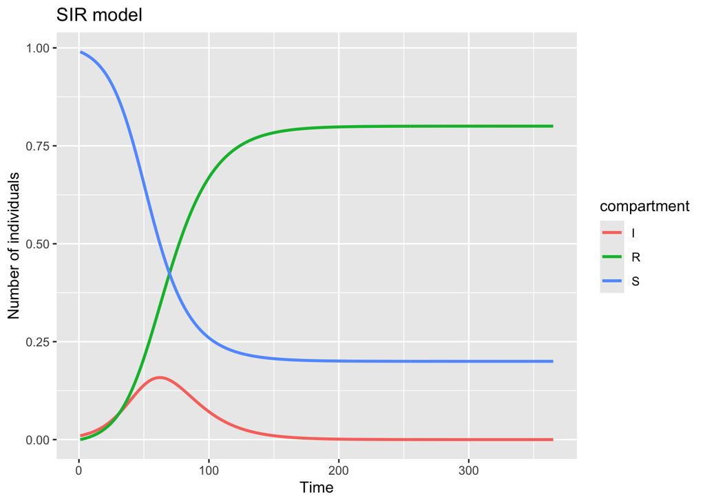

```r
# Load the necessary libraries
library(ggplot2)
library(tidyr)
# Create data for ggplot2 by reshaping
results_long <- results |>
  pivot_longer(
    cols = c(2:4),
    names_to = "compartment",
    values_to = "value"
  )

sir_plot <- ggplot(
  data = results_long,
  aes(
    x = time,
    y = value,
    color = compartment
  )
  ) +
  geom_line(linewidth = 1) +
  labs(
    title = "SIR model",
    x = "Time",
    y = "Number of individuals"
  )
plot(sir_plot)
```